# GES 001 演習6

H. Suzuki

2024-01-25

## 第6週

01/25(TH) 気候変動問題の原因：気候変動と経済活動1

気候変動問題の原因：気候変動と経済活2

第6週、第7週の講義では、気候変動が我々の生活にもたらす影響と対策を議論します。

基本的にIPCCの第6次評価報告書（https://www.data.jma.go.jp/cpdinfo/ipcc/index.html ）

をテキストに使っています。

01/30(TU) Rでデータサイエンス6：気候変動 [[Main](https://ds-sl.github.io/intro2r/ges001/ges001-main.nb.html)]・[授業]

Environment-Climate

CO2 emissions (metric tons per capita) ：EN.ATM.CO2E.PC [[Link](https://data.worldbank.org/indicator/EN.ATM.CO2E.PC)]

Forest area (% of land area)：AG.LND.FRST.ZS [[Link](https://data.worldbank.org/indicator/AG.LND.FRST.ZS)]

Renewable electricity output (% of total electricity output)：EG.ELC.RNEW.ZS [[Link](https://data.worldbank.org/indicator/EG.ELC.RNEW.ZS)]

Electricity production from oil, gas and coal sources (% of total)：EG.ELC.FOSL.ZS [[Link](https://data.worldbank.org/indicator/EG.ELC.FOSL.ZS)]

Electricity production from nuclear sources (% of total)：EG.ELC.NUCL.ZS [[Link](https://data.worldbank.org/indicator/EG.ELC.NUCL.ZS)]

IEA: Energy Statistics Data Browser データ元

https://www.iea.org/data-and-statistics/data-tools/energy-statistics-data-browser?country=WORLD&fuel=Energy%20supply&indicator=ElecGenByFuel

## 内容

- CO2 emissions (metric tons per capita) ：EN.ATM.CO2E.PC [[Link](https://data.worldbank.org/indicator/EN.ATM.CO2E.PC)]
- Forest area (% of land area)：AG.LND.FRST.ZS [[Link](https://data.worldbank.org/indicator/AG.LND.FRST.ZS)]
- Renewable electricity output (% of total electricity output)：EG.ELC.RNEW.ZS [[Link](https://data.worldbank.org/indicator/EG.ELC.RNEW.ZS)]
- Electricity production from oil, gas and coal sources (% of total)：EG.ELC.FOSL.ZS [[Link](https://data.worldbank.org/indicator/EG.ELC.FOSL.ZS)]
- Electricity production from nuclear sources (% of total)：EG.ELC.NUCL.ZS [[Link](https://data.worldbank.org/indicator/EG.ELC.NUCL.ZS)]

```r
df_environment <- WDI(
  indicator = c(co2pcap = "EN.ATM.CO2E.PC",
                forest = "AG.LND.FRST.ZS",
                renewable = "EG.ELC.RNEW.ZS",
                fossil = "EG.ELC.FOSL.ZS",
                nuclea = "EG.ELC.NUCL.ZS"
                ), extra = TRUE)
```

```r
write_csv(df_environment, "data/environment.csv")
```

```r
df_environment <- read_csv("data/environment.csv")
```

```r
df_environment_long <- df_environment |>
  pivot_longer(7:11, names_to = "name", values_to = "value")
```

```r
df_environment_long |>
  group_by(year, name) |> drop_na(value) |>
  summarize(num = n()) |> arrange(desc(year))
```

| year | name | num |
| --- | --- | --- |
| 2021 | forest | 262 |
| 2020 | co2pcap | 239 |
| 2020 | forest | 262 |
| 2019 | co2pcap | 239 |
| 2019 | forest | 262 |
| 2019 | renewable | 1 |
| 2018 | co2pcap | 239 |
| 2018 | forest | 262 |
| 2018 | renewable | 1 |
| 2017 | co2pcap | 239 |

[output cut: 195 more lines]

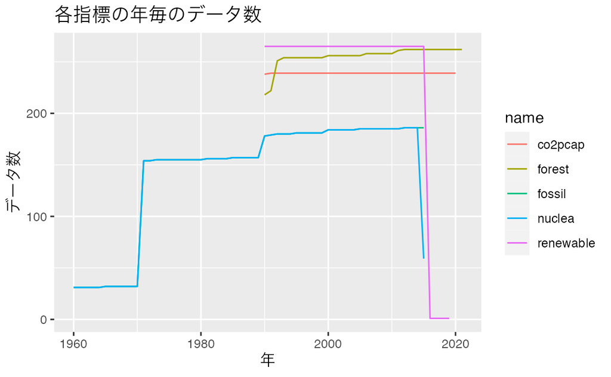

```r
df_environment_long |>
  group_by(year, name) |> drop_na(value) |>
  summarize(num = n()) |>
  ggplot(aes(year, num, col = name)) + geom_line() +
  labs(title = "各指標の年毎のデータ数", y = "データ数", x = "年")
```

World Development Indicators: [[Link](https://datacatalog.worldbank.org/search/dataset/0037712/World-Development-Indicators)]

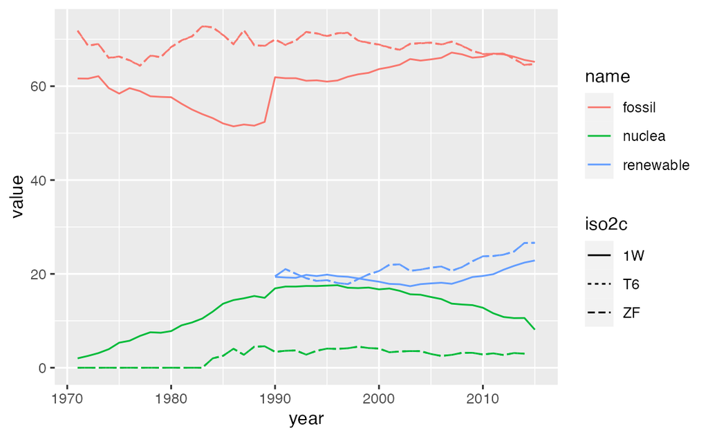

```r
df_environment_long |>
  filter(name %in% c("fossil", "renewable", "nuclea")) |>
  filter(iso2c %in% c("1W", "ZF", "T6")) |> drop_na(value) |>
  ggplot(aes(year, value, col = name, linetype = iso2c)) + geom_line()
```